# Project Part 2

2026-03-06

# 1. Introduction

## Main Question

This project examines whether being a Shooter video game causally increases global sales. Specifically, the question is:

**What is the effect of belonging to the Shooter genre on global sales of video games?**

The treatment variable (X) is an indicator equal to 1 if a game belongs to the Shooter genre, and 0 otherwise. The outcome variable (Y) is the global sales amount, measured in millions of copies sold.

This is a causal and economically meaningful question because we are not simply asking whether Shooter games sell more, but whether being a Shooter game causes higher sales.

## Why this question matters

This question is relevant to game developers, Publishers, investors, and platform companies such as Sony, Microsoft, and Nintendo. Knowing whether or not a certain genre (in this case shooter games) tends to generate higher sales is truly relevant to the gaming industry because it affects how development resources are allocated, how portfolios are structured, how marketing budgets are set, and even how platform exclusives are planned.

Moreover, understanding whether the genre itself increases sales (holding other factors constant) also helps business decision-makers make more informed strategic choices. If being a Shooter game truly causes higher sales, firms can adjust their investment and planning accordingly.

## Why this question is not obvious

This question is not obvious because simply observing that a certain genre sells more does not mean the genre itself causes higher sales. Several other factors could influence this relationship and are also correlated with whether a game is a Shooter.

Platform differences: Where some can have larger audiences or even favor/support specific genres of games (Which will reflect on the sales for that video game).

Time trends: The gaming market has expanded significantly over time (From 1980s to 2010s). This could also have the idea that there was greater digital distribution of games (more available), and that consumer preferences for certain genres could have changed over time.

Popular franchises: The popularity of certain game titles could also be another variable that impacts sales rather than simply just genre. This is because big game franchises will have loyal fan bases, receive large marketing budgets, and get a lot of repeat sales. More or less, higher sales could reflect more brand recognition rather than genre.

These factors all correlate with the Shooter variable, meaning they can create the appearance that Shooter games sell more even if the genre itself is not the true cause.

## Why descriptive statistics alone are not enough to answer this question and regression bias explanation.

These factors create the possibility of omitted variable bias: Shooter games may appear to sell more not because of their genre, but because they are disproportionately released on high‑selling platforms, in high‑demand years, or by large publishers. For these reasons, descriptive statistics alone cannot answer the causal question. The goal of this analysis is to explore the data, document the patterns we observe, and identify the confounding factors that must be addressed later in order to credibly estimate the causal effect of being a Shooter game on global sales.

# 2. About the Data

## Data Source

The dataset is widely used in academic and applied data analysis projects studying video game market performance.

## Unit of observation

Each row corresponds to a single game released on a specific platform.

## Frequency

Since it is based on release year of each video game, it is yearly data frequency.

## Variables

The dataset contains the following key variables:

Name: The title of the video game. Each observation corresponds to a specific game released on a specific platform.

Genre: The primary genre classification of the game (Action, Shooter, Sports, Role-Playing, etc.). This categorical variable identifies the type of gameplay and is used to construct the treatment indicator for Shooter games.

Publisher: The company responsible for publishing the game (Nintendo, Electronic Arts, Activision). This variable allows us to control for differences in marketing capacity, brand reputation, and distribution networks.

Platform: The gaming console on which the game was released (PlayStation 2, Xbox, Wii). Because platform popularity and install base vary substantially, this variable is an important control for market exposure.

Year: The year in which the game was released. This variable captures time trends in the gaming industry, including overall market growth and changes in consumer preferences.

Sales: Regional and global sales measured in millions of copies sold. The dataset includes: NA_Sales (North America), EU_Sales (Europe), JP_Sales (Japan), Other_Sales, and Global_Sales, which is the sum of regional sales

In this situation, Global_Sales is used as the primary outcome variable.

# 3. Analysis

In this section, we explore the relationship between Shooter games and global sales using descriptive statistics, visualizations, and preliminary regression analysis. The goal is not to estimate a causal effect yet, but to understand what the data suggest and identify the main sources of confounding that must be addressed later.

Because Shooter games are not randomly assigned across platforms or publishers, the descriptive patterns alone cannot be interpreted causally. The purpose of this section is to show how these underlying differences shape the raw Shooter–sales relationship and to motivate the need for a more careful empirical strategy in the future.

```
##   Rank                     Name Platform Year        Genre Publisher NA_Sales
## 1    1               Wii Sports      Wii 2006       Sports  Nintendo    41.49
## 2    2        Super Mario Bros.      NES 1985     Platform  Nintendo    29.08
## 3    3           Mario Kart Wii      Wii 2008       Racing  Nintendo    15.85
## 4    4        Wii Sports Resort      Wii 2009       Sports  Nintendo    15.75
## 5    5 Pokemon Red/Pokemon Blue       GB 1996 Role-Playing  Nintendo    11.27
## 6    6                   Tetris       GB 1989       Puzzle  Nintendo    23.20
##   EU_Sales JP_Sales Other_Sales Global_Sales Shooter
## 1    29.02     3.77        8.46        82.74       0
## 2     3.58     6.81        0.77        40.24       0
## 3    12.88     3.79        3.31        35.82       0
## 4    11.01     3.28        2.96        33.00       0
## 5     8.89    10.22        1.00        31.37       0
## 6     2.26     4.22        0.58        30.26       0
```

## Summary Statistics and Data Overview

[output not shown]

[output not shown]

```
##       Rank           Name             Platform             Year
##  Min.   :    1   Length:16598       Length:16598       Length:16598
##  1st Qu.: 4151   Class :character   Class :character   Class :character
##  Median : 8300   Mode  :character   Mode  :character   Mode  :character
##  Mean   : 8301
##  3rd Qu.:12450
##  Max.   :16600
##     Genre            Publisher            NA_Sales          EU_Sales
##  Length:16598       Length:16598       Min.   : 0.0000   Min.   : 0.0000
##  Class :character   Class :character   1st Qu.: 0.0000   1st Qu.: 0.0000
##  Mode  :character   Mode  :character   Median : 0.0800   Median : 0.0200
##                                        Mean   : 0.2647   Mean   : 0.1467
##                                        3rd Qu.: 0.2400   3rd Qu.: 0.1100
##                                        Max.   :41.4900   Max.   :29.0200
##     JP_Sales         Other_Sales        Global_Sales     Shooter
##  Min.   : 0.00000   Min.   : 0.00000   Min.   : 0.0100   0:15288
##  1st Qu.: 0.00000   1st Qu.: 0.00000   1st Qu.: 0.0600   1: 1310
##  Median : 0.00000   Median : 0.01000   Median : 0.1700
##  Mean   : 0.07778   Mean   : 0.04806   Mean   : 0.5374
##  3rd Qu.: 0.04000   3rd Qu.: 0.04000   3rd Qu.: 0.4700
##  Max.   :10.22000   Max.   :10.57000   Max.   :82.7400
```

```
##
## ====================================================
## Statistic      N      Mean    St. Dev.   Min   Max
## ----------------------------------------------------
## Rank         16,598 8,300.605 4,791.854   1   16,600
## NA_Sales     16,598   0.265     0.817   0.000 41.490
## EU_Sales     16,598   0.147     0.505   0.000 29.020
## JP_Sales     16,598   0.078     0.309   0.000 10.220
## Other_Sales  16,598   0.048     0.189   0.000 10.570
## Global_Sales 16,598   0.537     1.555   0.010 82.740
## ----------------------------------------------------
```

```
## [1] 579
```

The summary statistics show information about each column in the dataset, showing in particular the different ranges and averages for each region. This also shows that the dataset has 15,288 non-shooter games compared to only 1,310 shooters.

## Plots

These plots summarize mean sales for Shooter and non‑Shooter games, allowing us to compare average performance across years and regions.

### Time-Series Plot

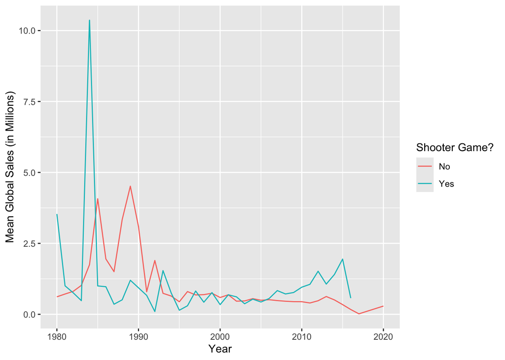

### Regional Sales Plots

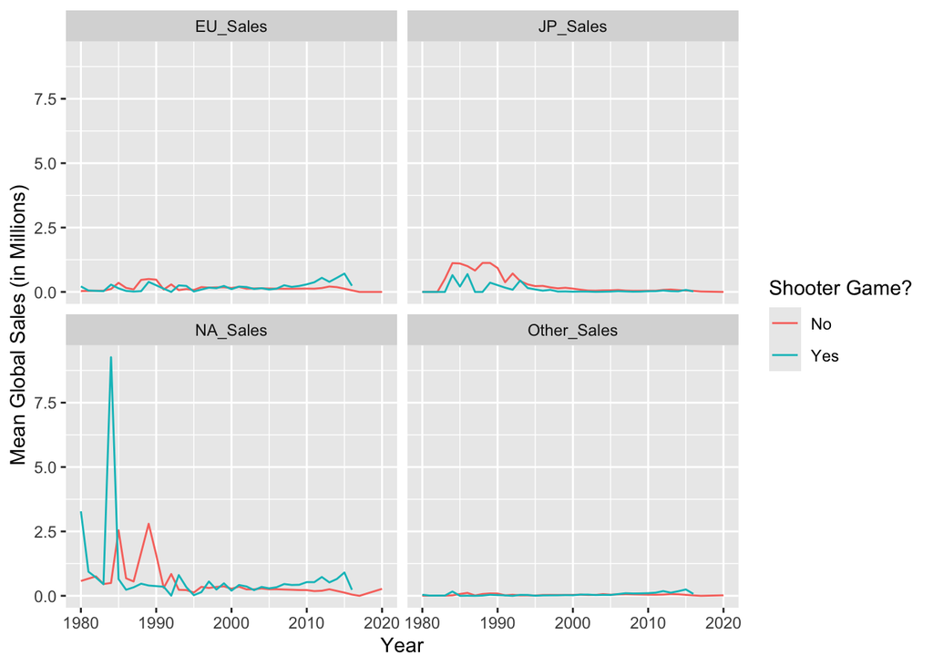

```
##   Rank      Name Platform Year   Genre Publisher NA_Sales EU_Sales JP_Sales
## 1   10 Duck Hunt      NES 1984 Shooter  Nintendo    26.93     0.63     0.28
##   Other_Sales Global_Sales Shooter
## 1        0.47        28.31       1
```

## Regression

### Simple Linear Regression

```
##
## Call:
## lm(formula = Global_Sales ~ Shooter, data = vgsales)
##
## Residuals:
##    Min     1Q Median     3Q    Max
## -0.782 -0.466 -0.356 -0.056 82.224
##
## Coefficients:
##             Estimate Std. Error t value Pr(>|t|)
## (Intercept)  0.51564    0.01256  41.046  < 2e-16 ***
## Shooter1     0.27625    0.04472   6.178 6.65e-10 ***
## ---
## Signif. codes:  0 '***' 0.001 '**' 0.01 '*' 0.05 '.' 0.1 ' ' 1
##
## Residual standard error: 1.553 on 16596 degrees of freedom
## Multiple R-squared:  0.002294,   Adjusted R-squared:  0.002234
## F-statistic: 38.16 on 1 and 16596 DF,  p-value: 6.654e-10
```

In a simple linear regression containing only the Shooter dummy variable, the coefficient is found to be statistically significant, providing evidence that a game’s status as a shooter or non-shooter game affects sales.

### Multiple Linear Regression

```
##
## Call:
##    felm(formula = Global_Sales ~ Shooter | Publisher, data = vgsales)
##
## Residuals:
##    Min     1Q Median     3Q    Max
## -2.754 -0.362 -0.121  0.033 80.208
##
## Coefficients:
##          Estimate Std. Error t value Pr(>|t|)
## Shooter1  0.24203    0.04483   5.398 6.82e-08 ***
## ---
## Signif. codes:  0 '***' 0.001 '**' 0.01 '*' 0.05 '.' 0.1 ' ' 1
##
## Residual standard error: 1.492 on 16018 degrees of freedom
## Multiple R-squared(full model): 0.1112   Adjusted R-squared: 0.07906
## Multiple R-squared(proj model): 0.001816   Adjusted R-squared: -0.03427
## F-statistic(full model):3.461 on 579 and 16018 DF, p-value: < 2.2e-16
## F-statistic(proj model): 29.14 on 1 and 16018 DF, p-value: 6.82e-08
```

```
##
## Call:
##    felm(formula = Global_Sales ~ Shooter | Platform, data = vgsales)
##
## Residuals:
##    Min     1Q Median     3Q    Max
## -2.544 -0.456 -0.235 -0.027 82.054
##
## Coefficients:
##          Estimate Std. Error t value Pr(>|t|)
## Shooter1  0.25923    0.04474   5.794 6.98e-09 ***
## ---
## Signif. codes:  0 '***' 0.001 '**' 0.01 '*' 0.05 '.' 0.1 ' ' 1
##
## Residual standard error: 1.527 on 16566 degrees of freedom
## Multiple R-squared(full model): 0.03808   Adjusted R-squared: 0.03628
## Multiple R-squared(proj model): 0.002023   Adjusted R-squared: 0.0001551
## F-statistic(full model):21.16 on 31 and 16566 DF, p-value: < 2.2e-16
## F-statistic(proj model): 33.57 on 1 and 16566 DF, p-value: 6.984e-09
```

```
##
## Call:
##    felm(formula = Global_Sales ~ Shooter | Year, data = vgsales)
##
## Residuals:
##    Min     1Q Median     3Q    Max
## -4.244 -0.429 -0.319 -0.040 82.242
##
## Coefficients:
##          Estimate Std. Error t value Pr(>|t|)
## Shooter1  0.27388    0.04434   6.177 6.69e-10 ***
## ---
## Signif. codes:  0 '***' 0.001 '**' 0.01 '*' 0.05 '.' 0.1 ' ' 1
##
## Residual standard error: 1.535 on 16557 degrees of freedom
## Multiple R-squared(full model): 0.02769   Adjusted R-squared: 0.02534
## Multiple R-squared(proj model): 0.002299   Adjusted R-squared: -0.0001112
## F-statistic(full model):11.79 on 40 and 16557 DF, p-value: < 2.2e-16
## F-statistic(proj model): 38.16 on 1 and 16557 DF, p-value: 6.686e-10
```

```
##
## Call:
##    felm(formula = Global_Sales ~ Shooter | Region, data = vgsales_long)
##
## Residuals:
##    Min     1Q Median     3Q    Max
## -0.782 -0.466 -0.356 -0.056 82.224
##
## Coefficients:
##          Estimate Std. Error t value Pr(>|t|)
## Shooter1  0.27625    0.02236   12.36   <2e-16 ***
## ---
## Signif. codes:  0 '***' 0.001 '**' 0.01 '*' 0.05 '.' 0.1 ' ' 1
##
## Residual standard error: 1.553 on 66387 degrees of freedom
## Multiple R-squared(full model): 0.002294   Adjusted R-squared: 0.002234
## Multiple R-squared(proj model): 0.002294   Adjusted R-squared: 0.002234
## F-statistic(full model):38.17 on 4 and 66387 DF, p-value: < 2.2e-16
## F-statistic(proj model): 152.7 on 1 and 66387 DF, p-value: < 2.2e-16
```

```
##
## Call:
##    felm(formula = Global_Sales ~ Shooter | Publisher + Platform +      Year + Region, data = vgsales_long)
##
## Residuals:
##    Min     1Q Median     3Q    Max
## -4.624 -0.379 -0.106  0.108 80.048
##
## Coefficients:
##          Estimate Std. Error t value Pr(>|t|)
## Shooter1  0.21207    0.02209   9.601   <2e-16 ***
## ---
## Signif. codes:  0 '***' 0.001 '**' 0.01 '*' 0.05 '.' 0.1 ' ' 1
##
## Residual standard error: 1.447 on 65740 degrees of freedom
## Multiple R-squared(full model): 0.1423   Adjusted R-squared: 0.1338
## Multiple R-squared(proj model): 0.0014   Adjusted R-squared: -0.008489
## F-statistic(full model):16.75 on 651 and 65740 DF, p-value: < 2.2e-16
## F-statistic(proj model): 92.18 on 1 and 65740 DF, p-value: < 2.2e-16
## *** Standard errors may be too high due to more than 2 groups and exactDOF=FALSE
```

## Conclusion and Causality:

Regressions with Publisher, Platform, Year, and Region respectively held as fixed effects produce results very similar to the simple linear regression, indicating that little omitted variable bias arises from the exclusion of these specific factors in the base model. Additionally, a model containing all of these factors as fixed effects produces results less similar to the simple model and the individual fixed effects models, but still at a fairly nonsubstantial magnitude, reinforcing these conclusions.

However, one important limitation that remains is the potential omission of game quality, an unobserved characteristic that is likely correlated with both genre and sales. Shooter games often share similar production values, design conventions, and franchise‑driven development cycles, which may make their average quality more homogeneous relative to other genres.If quality systematically differs between Shooter and non‑Shooter titles—and is not fully captured by publisher, platform, or year fixed effects—then the estimated Shooter coefficient may partially reflect these underlying quality differences rather than a pure genre effect. This remains a key source of unobserved heterogeneity that cannot be fully addressed with the available data.